hullBase

DATA501 project, R package version 0.1.0

Thanya Manivannan

# 1OVERVIEW

Project objective

- Address one limitation of the rubberband method, which is that the lower convex hull cannot follow a concave region of the baseline
- Keep the rubberband method as the primary method and add the detection and correction of concave regions

Package

- `hullBase`, version 0.1.0, MIT licence
- One main function, `correct()`, which returns a `BaselineModel`

Spectra hullBase is designed for

- hullBase corrects the baseline of FTIR spectra recorded as absorbance against wavenumber (cm⁻¹)
- In absorbance the peaks point upwards, so the rubberband lies underneath the spectrum
- Spectra recorded as transmittance are not corrected by hullBase and must be converted to absorbance, A = −log<sub>10</sub>(T), before calling `correct()`
- The baseline is a gradually shifting background below the peaks, and the corrected spectrum is y − b

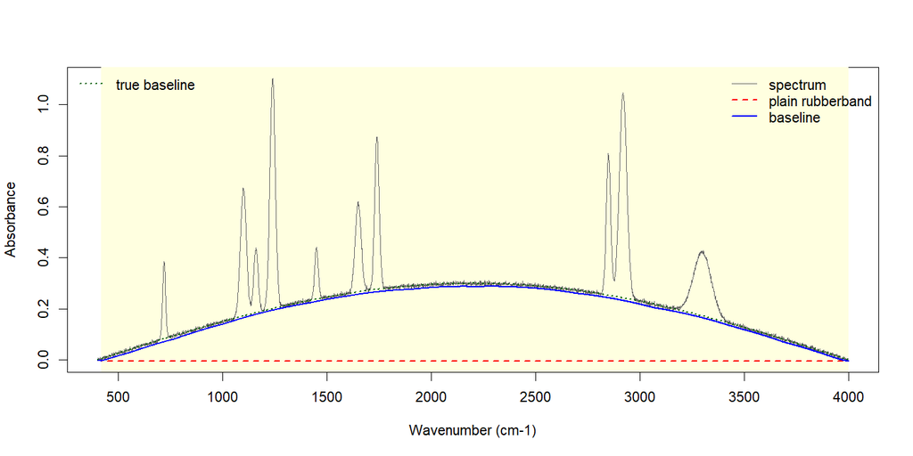

**Figure.** Simulated FTIR spectrum corrected by hullBase. The hullBase baseline follows the concave baseline when the spectrum is in absorbance and every peak is narrower than peak_width.

# 2LIMITATION THE PACKAGE ADDRESSES

How the plain rubberband works

- The rubberband stretches underneath the spectrum and touches the low lying points, called hull points
- The straight lines between neighbouring hull points are the hull segments
- At each hull point the hull can only bend upwards

The limitation

- Where the true baseline bends downwards, a concave region, the hull touches only the two ends of the region
- The hull segment runs straight underneath the concave region
- The gap between the segment and the true baseline remains in the corrected spectrum, so peaks on that region are measured too tall

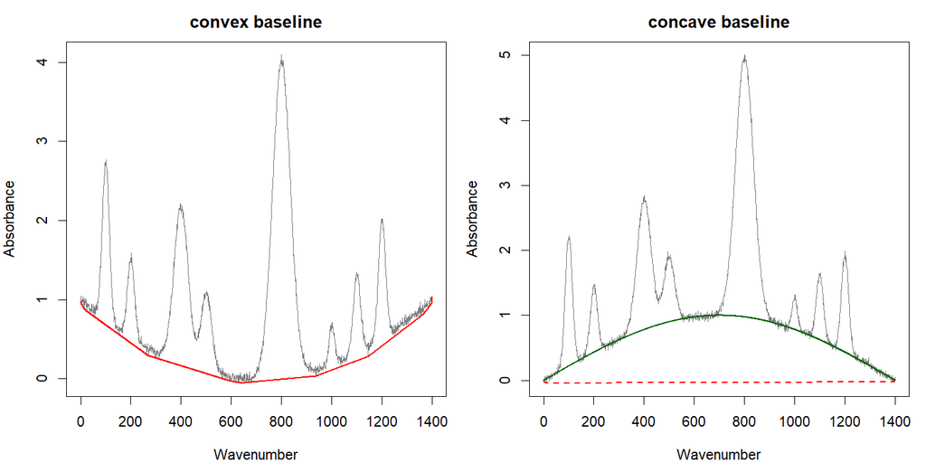

**Figure.** Example illustrating the limitation of the plain rubberband baseline, computed with `lower_hull()` on two spectra from `simulate_spectrum()`. Left, the hull follows the convex baseline. Right, the hull runs straight underneath the concave baseline.

Note

The package hullBase addresses only this limitation, where a hull segment runs straight underneath a concave region of the baseline.

# 3WHAT THE PACKAGE DOES

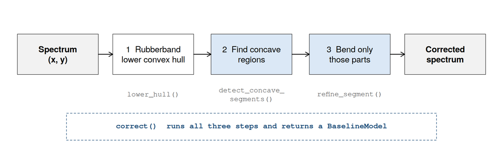

**Figure.** The three steps of the correction and the function that performs each one.

What changes

- Every hull segment of the plain rubberband is tested
- A flagged segment is bent locally to follow the concave region
- Every other segment keeps the plain rubberband line

What is calculated from the data

- Which segments to bend, from a threshold set from the noise level of the spectrum
- How strongly to bend, from the estimated height of the concave region
- `peak_width` is set by the user

# 4PACKAGE STRUCTURE AND MAIN FUNCTIONS

## 4.1PACKAGE NAME

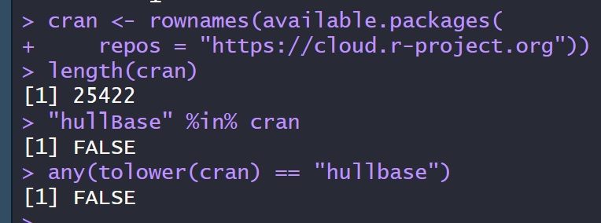

The package name is available. hullBase is not among the 25,422 packages on CRAN, in any letter case.

## 4.2FILES AND FOLDERS

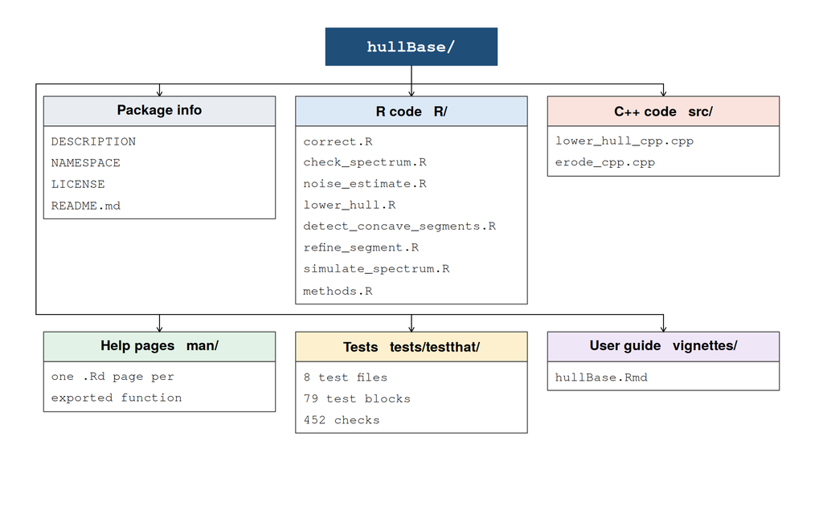

**Figure.** Package layout. R code in `R/`, C++ code in `src/`, tests in `tests/testthat/` and help pages in `man/`.

## 4.3THE SIX BUILDING BLOCKS

Main function

- `correct()` runs the full correction and returns a `BaselineModel`
- `lower_hull()`, `noise_estimate()`, `detect_concave_segments()` and `refine_segment()` can also be called on their own

S3 class and methods

- `BaselineModel` with `print()`, `summary()` and `plot()`
- `correct()` is an S3 generic with a default method and a data frame method

C++ functions

- `lower_hull_cpp()` builds the hull and `erode_cpp()` computes the moving minimum, both through Rcpp

Datasets

- `simulate_spectrum()` creates spectra with a known true baseline
- SrE.IR is loaded from its own package

Tests

- 8 test files, 79 `test_that()` blocks and 452 expectations

R CMD check

- 0 errors, 0 warnings and 0 notes

Note

A test block checks one rule, and an expectation is one single check inside it. Some blocks check the same rule on many different spectra, for example 50 random spectra, so one block can contain 50 checks. This is why 79 blocks give 452 expectations.

## 4.4S3 METHODS

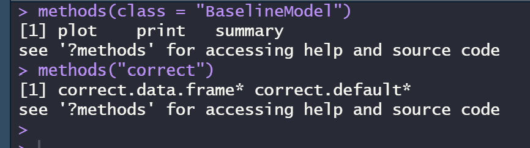

Registered methods. `plot()`, `print()` and `summary()` for `BaselineModel`, and the two methods of the `correct()` generic.

## 4.5DATA FLOW

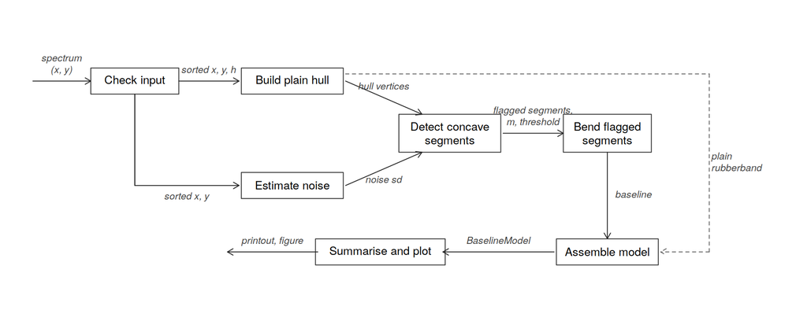

**Figure.** Data flow. The spectrum passes through the R functions and the two C++ functions and is returned as one BaselineModel.

## 4.6LAYERS

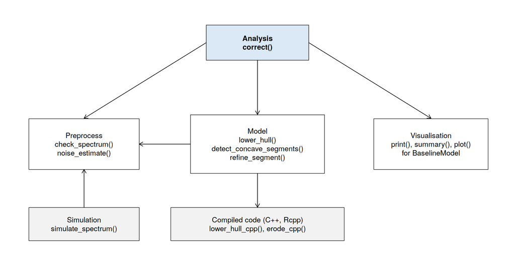

**Figure.** Package architecture. The functions a user calls, the R functions behind them and the compiled C++ layer.

# 5SIMULATED AND MEASURED SPECTRA USED FOR EVALUATION

| Dataset | Type | Spectra | Range | Source | Noise distribution |
| --- | --- | --- | --- | --- | --- |
| simulated spectra | simulated | 300 in the evaluation, 1 in each checkpoint | 0 to 1400 | created by `simulate_spectrum()` in hullBase | independent Gaussian noise |
| simulated FTIR spectra | simulated | 20 per test setting | 400 to 4000 cm⁻¹ | created by `simulate_spectrum()` in hullBase | independent Gaussian noise |
| SrE.IR | measured FTIR | 16 | 399.2 to 3999.8 cm⁻¹ | loaded from the ChemoSpec package | not Gaussian, suggests correlation (sample 1, 3700 to 3900 cm⁻¹) |

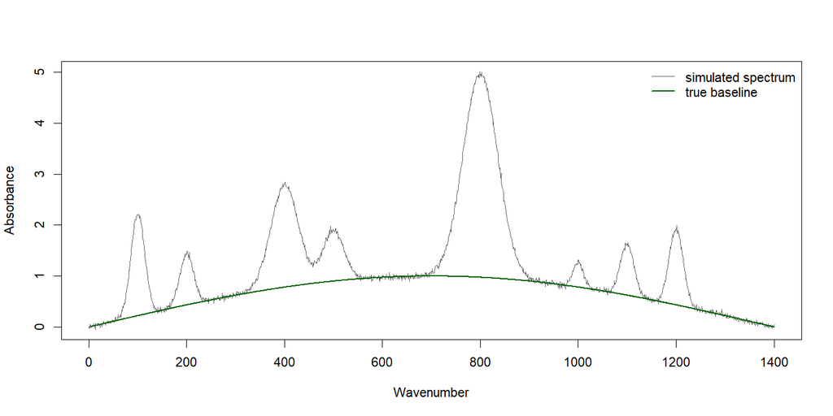

**Figure.** Simulated spectrum from 0 to 1400 with its true concave baseline, before correction.

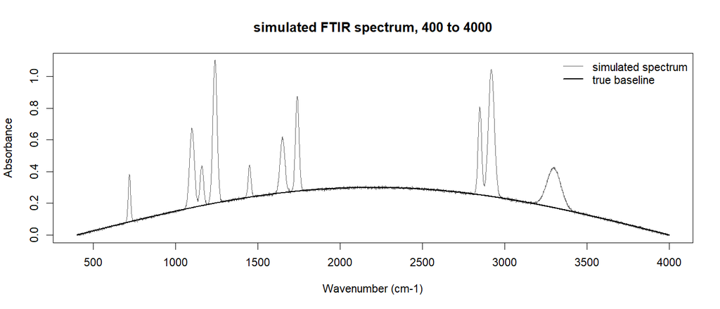

**Figure.** Simulated FTIR spectrum from 400 to 4000 cm⁻¹ with its true concave baseline, before correction.

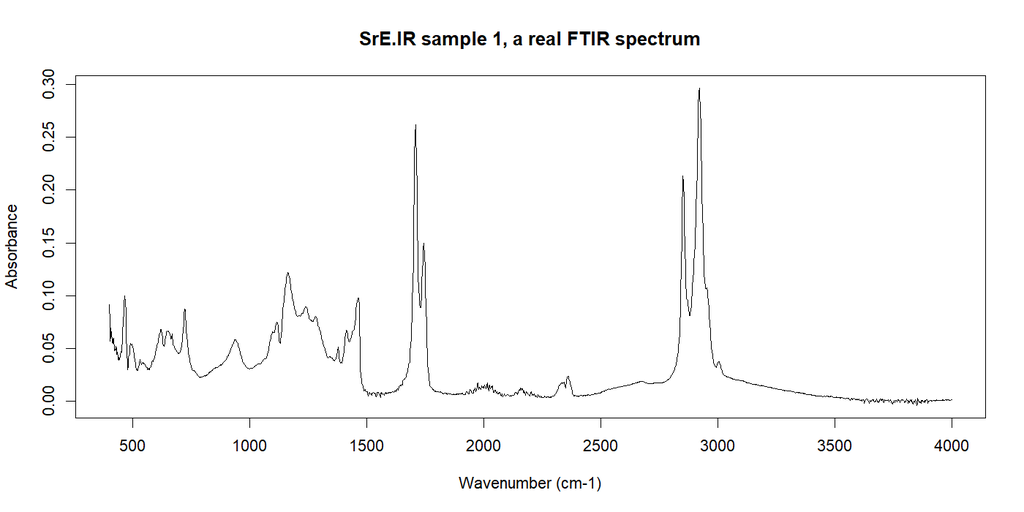

**Figure.** SrE.IR sample 1, measured FTIR spectrum, before correction.

What a simulated spectrum stores

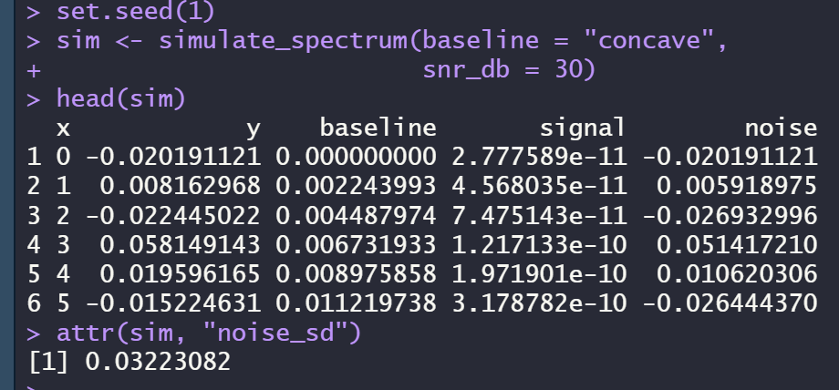

Every point stores its true baseline, signal and noise. The noise added at 30 dB is 0.0322.

Note

No measured data is stored in hullBase. SrE.IR is loaded from the ChemoSpec package, so its GPL data is not copied into the MIT licensed package.

Limitation

- One measured dataset with 16 spectra is a small sample
- Measured spectra have no known true baseline, so accuracy is measured only on simulated spectra
- The noise estimate and threshold in hullBase assume independent Gaussian noise, and the package was evaluated only on Gaussian peaks with independent Gaussian noise

# 6FROM INPUT SPECTRUM TO CORRECTED SPECTRUM, THE STEPS INSIDE correct()

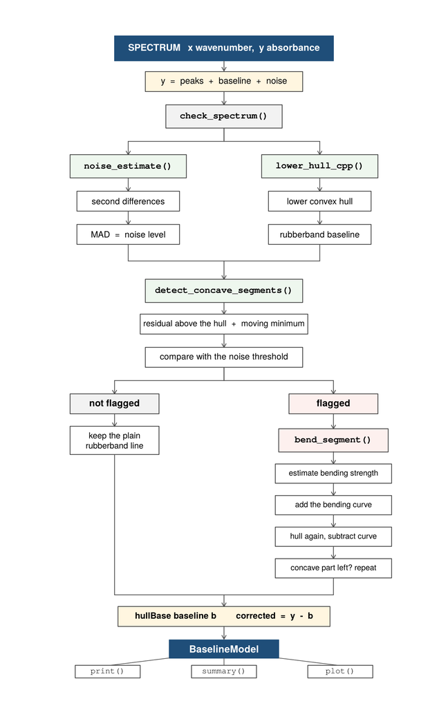

**Figure.** Every function call inside `correct()`, from the input spectrum to the BaselineModel.

## 6.1THE FUNCTIONS OF hullBase

| Function | Role |
| --- | --- |
| `correct()` | full correction, returns a `BaselineModel` |
| `lower_hull()` | plain rubberband baseline |
| `noise_estimate()` | noise standard deviation |
| `detect_concave_segments()` | flags hull segments |
| `refine_segment()` | bends one segment |
| `simulate_spectrum()` | test spectrum with a known baseline |
| `print()`, `summary()`, `plot()` | methods for `BaselineModel` |
| `lower_hull_cpp()`, `erode_cpp()` | internal C++ routines (Rcpp) |
| `check_spectrum()`, `bend_segment()` | internal R helpers |

## 6.2WHAT RUNS INSIDE EACH FUNCTION

| Main function | Functions called | Purpose |
| --- | --- | --- |
| `correct()` | `check_spectrum()` | check and sort the input |
|  | `noise_estimate()` | estimate the noise level |
|  | `lower_hull_cpp()` | find the hull points (C++) |
|  | `detect_concave_segments()` | flag the hull segments that hide a concave region |
|  | `bend_segment()` | bend each flagged segment |
| `detect_concave_segments()` | `lower_hull_cpp()` | find the hull points (C++) |
|  | `erode_cpp()` | moving minimum (C++) |
| `refine_segment()` | `bend_segment()` | bend, and repeat on any remaining part (up to 3 levels) |
| `lower_hull()` | `lower_hull_cpp()` | find the hull points (C++) |
| `noise_estimate()` | `mad()` | spread of the second differences |

## 6.3THE TWO LOOPS INSIDE correct()

- Loop 1 visits every hull segment and decides whether it hides a concave region
- Loop 2 visits only the flagged segments and bends each one

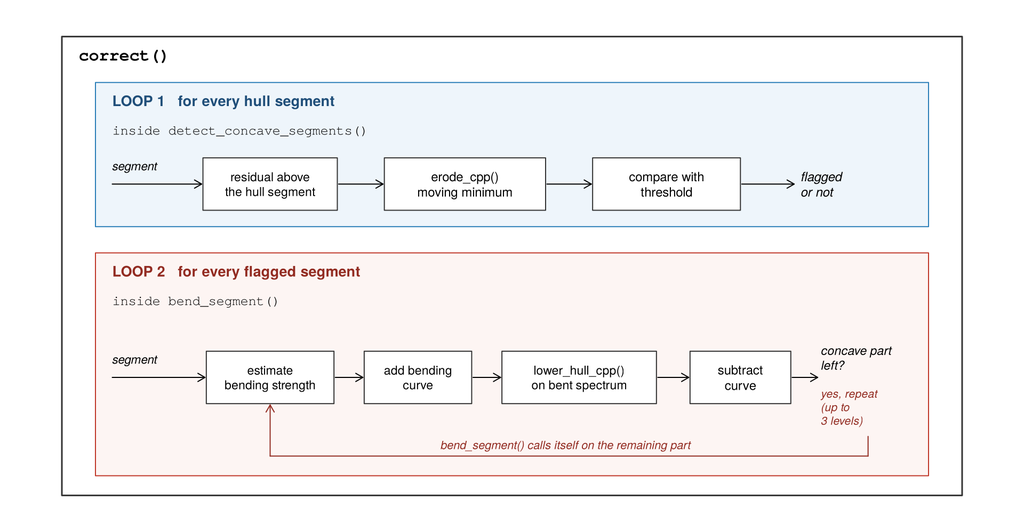

**Figure.** The two loops. Every hull segment is tested once, and only flagged segments are bent.

## 6.4THE CHECKPOINTS

| Checkpoint | Topic | Main functions |
| --- | --- | --- |
| A | Preprocessing the input spectrum | `check_spectrum()` |
| B | Constructing the lower convex hull | `lower_hull()`, `lower_hull_cpp()` |
| C | Estimating noise and detecting concave regions | `detect_concave_segments()`, `noise_estimate()`, `erode_cpp()` |
| D | Bending a flagged segment | `bend_segment()`, `refine_segment()` |
| E | Returning and inspecting a BaselineModel | `correct()`, `print()`, `summary()`, `plot()` |

# 7CHECKPOINT A: PREPROCESSING THE INPUT SPECTRUM

MAIN FUNCTION`check_spectrum()`

PURPOSE

`check_spectrum()` checks the input spectrum and stops invalid input before any baseline correction is done.

IMPLEMENTATION

`check_spectrum()` is called first by every function that takes a spectrum, sorts the points by wavenumber and checks the spacing against h, the median step.

EVIDENCE

[output not shown]

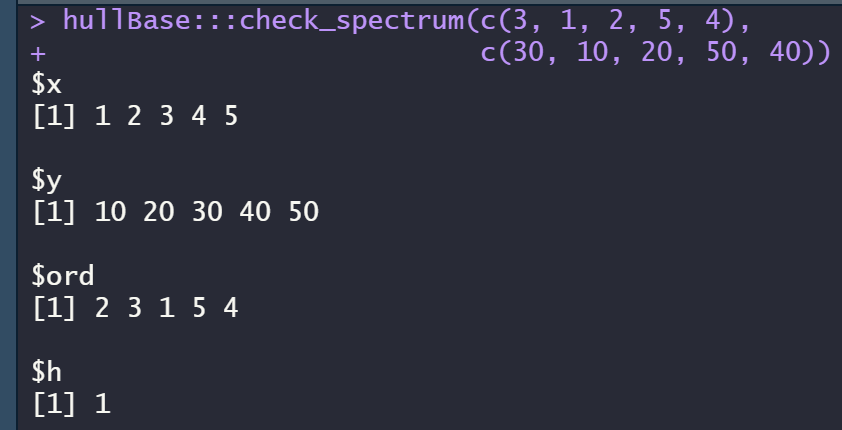

Valid input passes `check_spectrum()` and returns the sorted spectrum and h.

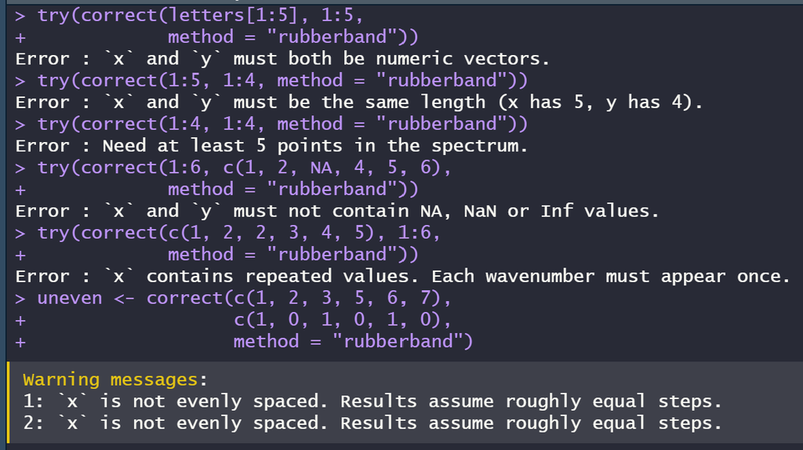

Invalid input is stopped by `check_spectrum()` with its own message for each problem.

Limitation

- Repeated wavenumbers, unevenly spaced wavenumbers and transmittance spectra must be prepared by the user before calling `correct()`.

# 8CHECKPOINT B: CONSTRUCTING THE LOWER CONVEX HULL

MAIN FUNCTION`lower_hull()`

PURPOSE

`lower_hull()` computes the plain rubberband baseline, which is the starting baseline of hullBase.

IMPLEMENTATION

`lower_hull()` passes the sorted points to `lower_hull_cpp()`, which finds the hull points with Andrew’s monotone chain algorithm and the 2D cross product, in one scan from left to right.

EVIDENCE

163 expectations in test-lower_hull.R pass, including the comparison with `grDevices::chull()` on 50 random spectra.

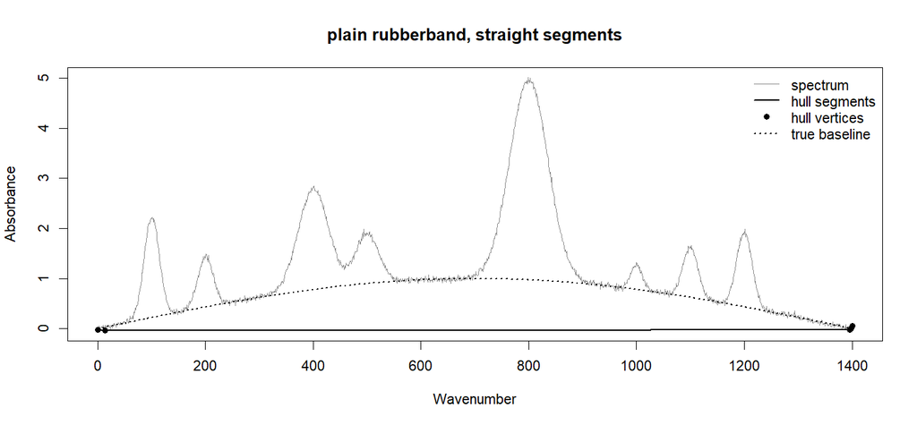

**Figure.** Plain rubberband baseline computed with `lower_hull()` on a simulated spectrum. The hull segments run straight underneath the concave true baseline.

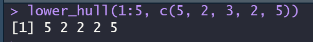

`lower_hull()` on y = 5, 2, 3, 2, 5 removes the point lying above the line between its neighbours and returns 5, 2, 2, 2, 5.

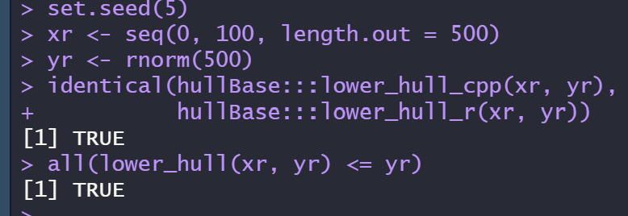

`lower_hull_cpp()` and `lower_hull_r()` give identical hull points on one spectrum of 500 random points, and the baseline never goes above the data.

# 9CHECKPOINT C: ESTIMATING NOISE AND DETECTING CONCAVE REGIONS

MAIN FUNCTION`detect_concave_segments()`

PURPOSE

`detect_concave_segments()` flags only the hull segments that hide a concave region, so that only those segments are bent in Checkpoint D.

IMPLEMENTATION

| Function called inside detect_concave_segments() | What it does |
| --- | --- |
| `check_spectrum()` | checks and sorts the input spectrum, and returns the step h |
| `noise_estimate()` | estimates the noise level of the spectrum from its second differences, when the user does not give a noise value |
| `lower_hull_cpp()` | finds the hull points, and gives the hull segments to be checked |
| `erode_cpp()` | applies a moving minimum as wide as `peak_width` to the residual above each hull segment, so the peaks are removed and the concave region remains |

`detect_concave_segments()` flags a segment when its largest eroded value exceeds the threshold calculated from the noise level, and returns a table of the decision for every hull segment.

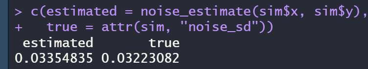

`noise_estimate()` on the simulated spectrum gives 0.0335 against the true noise standard deviation of 0.0322.

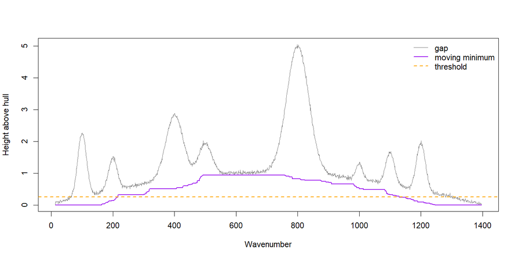

**Figure.** The residual above the hull segment from 13 to 1396 and its moving minimum from `erode_cpp()`. The moving minimum removes the peaks, and the eroded residual of the concave region exceeds the threshold.

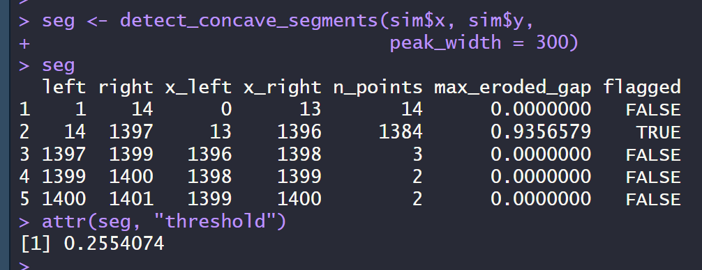

`detect_concave_segments()` with peak_width = 300 returns one row for each of the five hull segments, and only the segment from 13 to 1396 is flagged, with a largest eroded value of 0.936 against the threshold of 0.255.

Limitation

- `detect_concave_segments()` cannot tell a peak wider than `peak_width` apart from a concave region, so the user must set `peak_width` at least as wide as the widest peak.
- `detect_concave_segments()` does not flag a concave region lower than the threshold, so under such a region the plain rubberband line remains.
- `detect_concave_segments()` calculates the threshold from `noise_estimate()`, which assumes the noise of neighbouring points is independent, so on spectra with correlated noise, such as SrE.IR, the threshold may be set too high or too low.

# 10CHECKPOINT D: BENDING A FLAGGED SEGMENT

MAIN FUNCTION`bend_segment()`

called by `correct()` for each flagged segment, and available to the user through `refine_segment()`

PURPOSE

`bend_segment()` replaces the straight hull line under a flagged segment with a baseline that follows the concave region, while every other segment keeps the plain rubberband line.

IMPLEMENTATION

| Function called inside bend_segment() | What it does |
| --- | --- |
| `erode_cpp()` | removes the peaks from the residual above the flagged segment, so the height of the concave region can be estimated |
| `lower_hull_cpp()` | takes the lower convex hull of the spectrum after the bending curve is added |
| `bend_segment()` | calls itself on any part of the concave region that still exceeds the threshold, up to 3 levels |

`bend_segment()` adds a bending curve with strength twice the estimated height, takes the hull, then subtracts the curve.

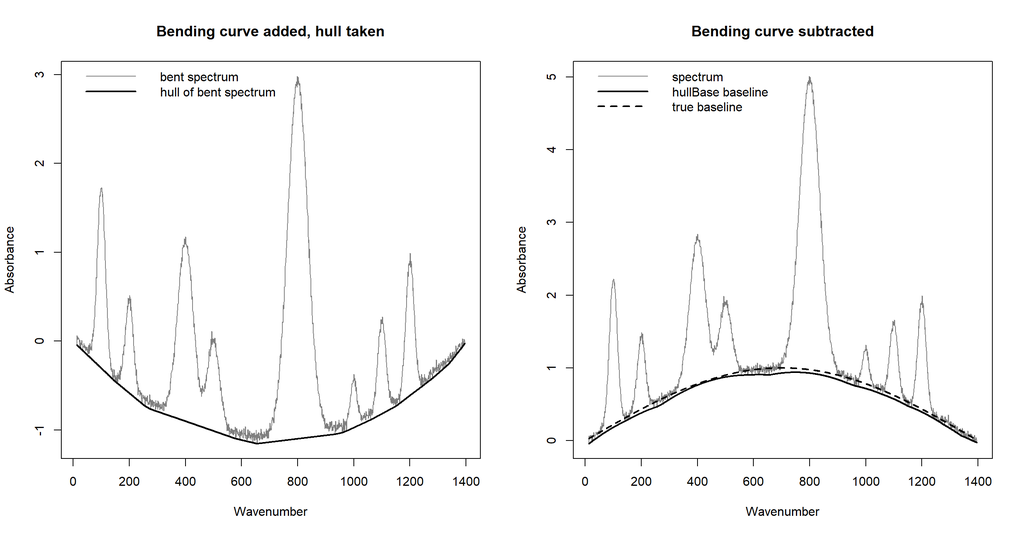

**Figure.** Left, the flagged segment from 13 to 1396 with the bending curve added, and the hull of the bent spectrum. Right, the hullBase baseline after the bending curve is subtracted, with the true baseline.

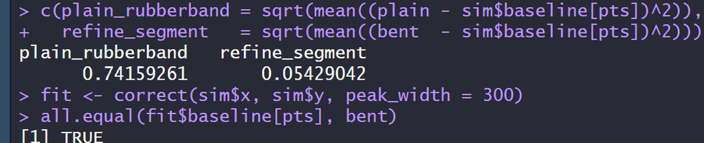

`refine_segment()` on the flagged segment lowers the RMSE against the true baseline from 0.742 for the plain rubberband baseline to 0.054, and `correct()` gives the same baseline on this segment.

Limitation

- `bend_segment()` gives a baseline made of straight lines joined at corners, not a smooth curve.
- `bend_segment()` uses `bend_factor` = 2, which was tested only on the half sine concave baseline of the simulated spectra.

# 11CHECKPOINT E: RETURNING AND INSPECTING A BaselineModel

MAIN FUNCTION`correct()`

PURPOSE

`correct()` runs every checkpoint in order and returns one `BaselineModel` object that holds the result and the information needed to inspect it.

IMPLEMENTATION

| Function called inside correct() | What it does |
| --- | --- |
| `check_spectrum()` | checks and sorts the input spectrum |
| `noise_estimate()` | estimates the noise level when the user does not give one |
| `lower_hull_cpp()` | gives the plain rubberband baseline, which is stored for comparison |
| `detect_concave_segments()` | flags the hull segments that hide a concave region |
| `bend_segment()` | bends each flagged segment |

`correct()` is an S3 generic with a default method for x and y, and a method for a data frame. Its result has `print()`, `summary()` and `plot()` methods.

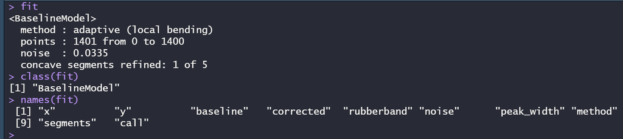

`correct()` returns an object of class BaselineModel with 10 fields, and `print()` shows that one of five hull segments was refined.

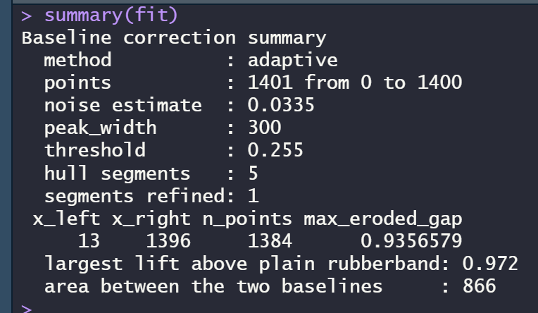

`summary()` reports the noise estimate, the threshold, the refined segment from 13 to 1396 and how far the baseline was lifted above the plain rubberband baseline.

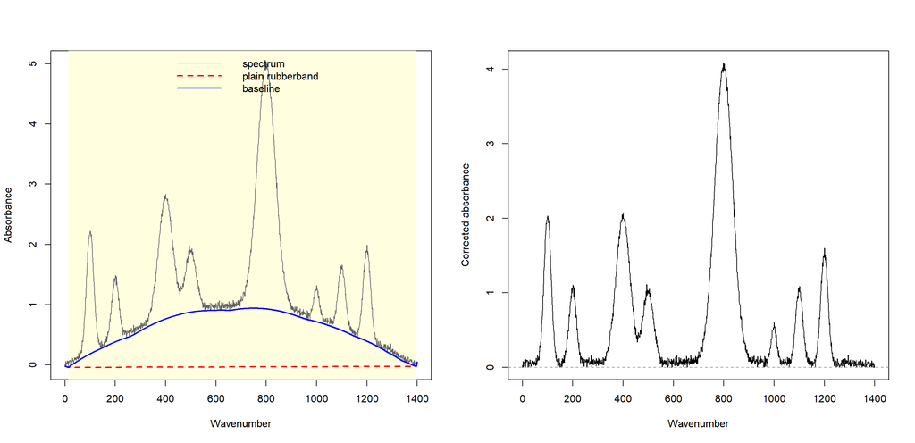

**Figure.** Left, `plot()` shows the spectrum with the plain rubberband baseline and the hullBase baseline, and shades the refined segment. Right, `plot()` with which = "corrected" shows the corrected spectrum.

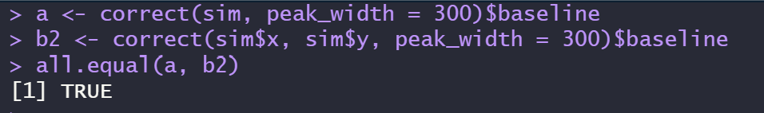

The data frame method and the default method of `correct()` give the same baseline.

Limitation

- `correct()` has no default value for `peak_width`, so the result depends on a value the user must choose, and a `peak_width` smaller than the widest peak leaves that peak treated as part of the concave region.
- `correct()` does not record how many bending levels were used, so when the limit of 3 levels is reached, the user is not told that part of the concave region may still remain above the baseline.
- `correct()` corrects one spectrum per call, so the user must write a loop to correct a set of spectra, and the same `peak_width` is then applied to every spectrum unless the user changes it.

# 12RESULTS ON EVERY DATASET

## 12.1SIMULATED SPECTRA

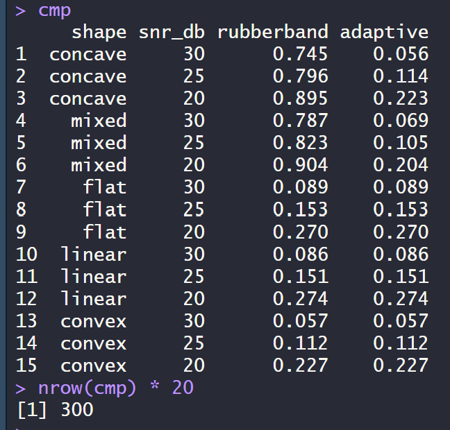

Mean RMSE against the true baseline over 20 spectra for each baseline shape and noise level, for the plain rubberband baseline and for hullBase.

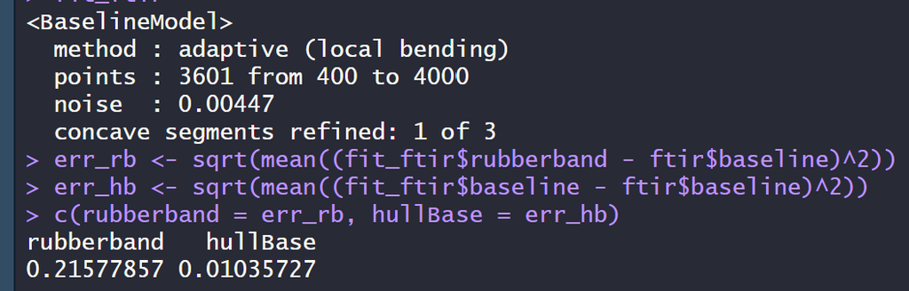

On the simulated FTIR spectrum, `correct()` refines one of three hull segments, and the RMSE against the true baseline falls from 0.216 to 0.010.

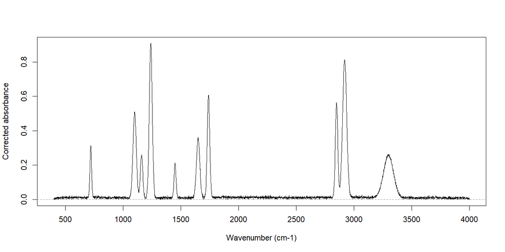

**Figure.** Corrected simulated FTIR spectrum from 400 to 4000 cm⁻¹.

RESULT

The RMSE for concave and mixed baselines falls at every noise level. For flat, linear and convex baselines it is unchanged, because no segment is flagged.

CONDITIONS

Conditions of the simulated spectra under which this result was obtained

- the noise is independent and Gaussian, so `noise_estimate()` gives the noise standard deviation and the threshold is at the intended level
- every peak is Gaussian and narrower than `peak_width` = 300, so the moving minimum removes every peak
- the spectrum is in absorbance and evenly spaced, with each wavenumber only once
- the concave baseline has a half sine profile of height 1, which is above the threshold

Limitation

- `simulate_spectrum()` creates spectra that meet every condition above, so the result does not show how hullBase performs when one of these conditions does not hold.
- The result was obtained with `peak_width` = 300 and `bend_factor` = 2 only, so the effect of other values on the error was not measured.
- The hullBase error on concave baselines rises from 0.056 at 30 dB to 0.223 at 20 dB, so the improvement is smaller on noisier spectra.

## 12.2MEASURED SPECTRA

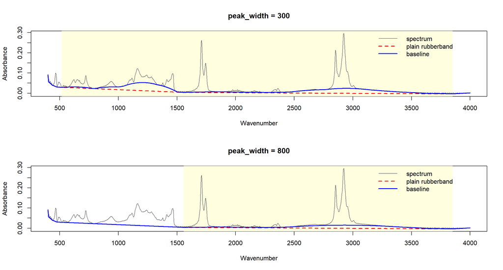

**Figure.** SrE.IR sample 1 corrected with peak_width = 300 (top) and peak_width = 800 (bottom). The baseline under the band group from 500 to 1500 cm⁻¹ is lifted at peak_width = 300 and follows the plain rubberband line at peak_width = 800.